# BBT045: Intro to R programming for data analysis

Filip Buric

2021-01-27

# 1 Intro

This module will be relying on the following material, which you are encouraged to read more extensively beyond the requirement for this course. Becoming comfortable (not only familiar) with a programming language is a like a superpower and you’ll find it enables you to do many more things beyond the initial context (and enhances your employment outlook).

- [*Advanced R*](https://adv-r.hadley.nz) by Hadley Wickham. Don’t let the name fool you, it’s simply a more systematic and technical overview of the language. Even if you don’t understand much of it now, it’s a good book to come back to later.
- [*R for Data Science*](https://r4ds.had.co.nz) by Hadley Wickham As the title implies, it focuses more on workflows and good practices for data science.
- Miscellaneous :) There are many good resource on the web. We’ll point out some when relevant.

For this module, please read the sections we point out.

If you’re curious about some pros and cons of the R programming language, **read sections 1.1 and 1.2** from *Advanced R*: https://adv-r.hadley.nz/introduction.html

## 1.1 Getting help

Most R functions and libraries have good documentation. In RStduio, select a function and press `F1` to have the documentation appear in the *Help* tab (to the lower-right). In an R console, run `?function` to display the same documentation on screen. Googling is of course an alternative

# 2 Prep

You can download a copy of this notebook here.

Install the tidyverse packages:

```r
if (!require("tidyverse"))
  install.packages("tidyverse")
```

# 3 R Environments

One usually needs a collection of different R libraries within a workflow. Many functions in these packages have the same name and only the functions from the last imported library are “remembered” by R.

But we can explicitly refer to a function in a package by using the syntax

`package::function()`

This can be cumbersome but advised when working with multiple packages.

You can get a list of the loaded environment with the `search()` function

```r
base::search()
```

```
##  [1] ".GlobalEnv"        "package:forcats"   "package:stringr"
##  [4] "package:dplyr"     "package:purrr"     "package:readr"
##  [7] "package:tidyr"     "package:tibble"    "package:ggplot2"
## [10] "package:tidyverse" "package:stats"     "package:graphics"
## [13] "package:grDevices" "package:utils"     "package:datasets"
## [16] "package:methods"   "Autoloads"         "package:base"
```

# 4 Working with R data structures

R uses a number of different data structures (vector, matrices, lists, objects, data frames, etc.) and allows users to create their own. Which is why one should be aware of some general principles, as some package creators get overenthusiastic about they way they package output from their functions.

## 4.1 Attributes

R data structures can be “decorated” by setting attributes. To set these, use the `attr()` function:

```r
my_vector <- 1:10
attr(my_vector, "about") <- "this is just a simple sequence"

my_vector
```

```
##  [1]  1  2  3  4  5  6  7  8  9 10
## attr(,"about")
## [1] "this is just a simple sequence"
```

These attributes are printed along with the variable, but can also be fetched as a list with `attributes`:

```r
attributes(my_vector)
```

```
## $about
## [1] "this is just a simple sequence"
```

Some attributes are generally recognized by various functions so they have specialized ways to access / set them, like `names()`

```r
names(my_vector) <- c("one", "two", "three", "four", "five")

my_vector
```

```
##   one   two three  four  five  <NA>  <NA>  <NA>  <NA>  <NA>
##     1     2     3     4     5     6     7     8     9    10
## attr(,"about")
## [1] "this is just a simple sequence"
```

As you can see, the `print()` function expects to match each element of the vector with a name.

Besides meta-information, attributes can have a functional role, as they inform various functions how to interpret and process these data structures.

A typical example are matrices, which are simply vectors, with the number of rows and columns set as attributes:

```r
dim(my_vector) <- c(2, 5)
my_vector
```

```
##      [,1] [,2] [,3] [,4] [,5]
## [1,]    1    3    5    7    9
## [2,]    2    4    6    8   10
## attr(,"about")
## [1] "this is just a simple sequence"
```

This is equivalent to using the built-in `matrix()` creation function:

```r
my_matrix <- matrix(1:10, nrow = 2, ncol = 5)
my_matrix
```

```
##      [,1] [,2] [,3] [,4] [,5]
## [1,]    1    3    5    7    9
## [2,]    2    4    6    8   10
```

**Note** Attributes are meant to be transient. Many functions remove them.

## 4.2 S3 Objects

These are basically data structures with permanent attributes (meaning functions cannot remove them).

The way to create these is simply to set a `class` attribute. (An object is a single instance of a generic class of data structures)

```r
attr(my_matrix, "class") <- "named_matrix"
attr(my_matrix, "row_names") <- c("one", "two")
attr(my_matrix, "column_names") <- c("one", "two", "three", "four", "five")

my_matrix
```

```
##      [,1] [,2] [,3] [,4] [,5]
## [1,]    1    3    5    7    9
## [2,]    2    4    6    8   10
## attr(,"class")
## [1] "named_matrix"
## attr(,"row_names")
## [1] "one" "two"
## attr(,"column_names")
## [1] "one"   "two"   "three" "four"  "five"
```

Or, in one step:

```r
structure(matrix(1:10, nrow = 2, ncol = 5),
          class = "named_matrix",
          row_names = c("one", "two"),
          column_names = c("one", "two", "three", "four", "five")
          )
```

```
##      [,1] [,2] [,3] [,4] [,5]
## [1,]    1    3    5    7    9
## [2,]    2    4    6    8   10
## attr(,"class")
## [1] "named_matrix"
## attr(,"row_names")
## [1] "one" "two"
## attr(,"column_names")
## [1] "one"   "two"   "three" "four"  "five"
```

All of this is mostly relevant for certain functions and it’s the “magic” behind some fancy data types like data frames.

S3 objects are extremely common in the R landscape and many functions return output like this, so it’s good to be aware of how they’re structured.

Besides S3, there are S4 and R6 object types (helpful names, huh?). If you’re curious or need to understand some output in these formats, refer to [Objected-oriented programming](https://adv-r.hadley.nz/oo.html) in the *Advanced R* book.

## 4.3 Lists

These are a more flexible structure, as they can contain multiple entries, of any data type:

```r
shopping_list <- list(
    items = c("chocolate", "bread", "broccoli"),
    prices = c(15, 45, 32),
    date = "2021-02-01"
)
```

## 4.4 Strings

Text aka “character” strings can be manipulated in different ways. R has built-in functions for this but take a look at the [stringr](https://cran.r-project.org/web/packages/stringr/stringr.pdf) package that offers convenient functions

```r
message <- "hello world"

nchar(message)
```

```
## [1] 11
```

You can extract parts of a string using numerical positions

```r
substr(message, start = 1, stop = 5)
```

```
## [1] "hello"
```

You can replace certain patterns:

```r
library(stringr)

stringr::str_replace(message, pattern = "o", replacement = "-")
```

```
## [1] "hell- world"
```

```r
stringr::str_replace_all(message, pattern = "o", replacement = "-")
```

```
## [1] "hell- w-rld"
```

`str_replace()` and `str_replace_all()` can be applied on vectors and accepts more complicated (regex) patterns:

```r
fruits <- c("one apple", "two pears", "three bananas")

stringr::str_replace_all(fruits, pattern = "[aeiou]", replacement = "-")
```

```
## [1] "-n- -ppl-"     "tw- p--rs"     "thr-- b-n-n-s"
```

To search for a string inside another larger string or for a certain pattern of possible strings inside a larger string, you can use the `stringr::str_locate()` and `stringr::str_locate_all()` functions.

```r
fruit <- c("apple", "banana", "pear", "pineapple")
stringr::str_locate(fruit, "a")
```

```
##      start end
## [1,]     1   1
## [2,]     2   2
## [3,]     3   3
## [4,]     5   5
```

```r
stringr::str_locate_all(fruit, "a")
```

```
## [[1]]
##      start end
## [1,]     1   1
##
## [[2]]
##      start end
## [1,]     2   2
## [2,]     4   4
## [3,]     6   6
##
## [[3]]
##      start end
## [1,]     3   3
##
## [[4]]
##      start end
## [1,]     5   5
```

## 4.5 Inspecting data structures

You can see what type of data structure a variable is by using the `class()` function.

```r
class(shopping_list)
```

```
## [1] "list"
```

To see what the underlying data *type* (i.e. nunber, character) a variable has, you can use the `typeof()` function.

```r
typeof(my_matrix)
```

```
## [1] "integer"
```

For our toy matrix, this is number (integer, to be exact).

To get elements out of various data structures there are a few access operators.

```r
my_vector[3]
```

```
## [1] 3
```

```r
shopping_list$items
```

```
## [1] "chocolate" "bread"     "broccoli"
```

```r
shopping_list[["items"]]
```

```
## [1] "chocolate" "bread"     "broccoli"
```

```r
shopping_list$items[1]
```

```
## [1] "chocolate"
```

There many more useful ways you can fetch elements and you are strongly encouraged to at least browse through the [Subsetting](https://adv-r.hadley.nz/subsetting.html) chapter of the *Advanced R* book, at least to be aware.

# 5 Working with Tabular Data

Many datasets can naturally be organized in tables. Base R already has the `data.frame` data structure but we’ll be using its “upgraded” version (a so-called “tibble”), along with associated functions from the `dplyr` library, part of the `tidyverse` collection of packages.

These functions allow for a programming style that combines functional elements with query-like steps.

Here’s a quick reference for the operations we’ll be using: [Data Wrangling Cheat Sheet](https://rstudio.com/wp-content/uploads/2015/02/data-wrangling-cheatsheet.pdf)

Let’s use the (R built-in) Iris dataset to illustrate some ways we can work with tables.

```r
library(tidyverse)
```

```r
iris
```

| Sepal.Length | Sepal.Width | Petal.Length | Petal.Width | Species |
| --- | --- | --- | --- | --- |
| 5.1 | 3.5 | 1.4 | 0.2 | setosa |
| 4.9 | 3.0 | 1.4 | 0.2 | setosa |
| 4.7 | 3.2 | 1.3 | 0.2 | setosa |
| 4.6 | 3.1 | 1.5 | 0.2 | setosa |
| 5.0 | 3.6 | 1.4 | 0.2 | setosa |
| 5.4 | 3.9 | 1.7 | 0.4 | setosa |
| 4.6 | 3.4 | 1.4 | 0.3 | setosa |
| 5.0 | 3.4 | 1.5 | 0.2 | setosa |
| 4.4 | 2.9 | 1.4 | 0.2 | setosa |
| 4.9 | 3.1 | 1.5 | 0.1 | setosa |

[output cut: 140 more lines]

## 5.1 Filtering rows based on values

```r
iris %>%
    dplyr::filter(Species == "setosa")
```

| Sepal.Length | Sepal.Width | Petal.Length | Petal.Width | Species |
| --- | --- | --- | --- | --- |
| 5.1 | 3.5 | 1.4 | 0.2 | setosa |
| 4.9 | 3.0 | 1.4 | 0.2 | setosa |
| 4.7 | 3.2 | 1.3 | 0.2 | setosa |
| 4.6 | 3.1 | 1.5 | 0.2 | setosa |
| 5.0 | 3.6 | 1.4 | 0.2 | setosa |
| 5.4 | 3.9 | 1.7 | 0.4 | setosa |
| 4.6 | 3.4 | 1.4 | 0.3 | setosa |
| 5.0 | 3.4 | 1.5 | 0.2 | setosa |
| 4.4 | 2.9 | 1.4 | 0.2 | setosa |
| 4.9 | 3.1 | 1.5 | 0.1 | setosa |

[output cut: 40 more lines]

Note the pipe operator `%>%` above, introduced by the tidyverse library. It’s very similar to the Unix pipe `|` in that it feeds the value / variable on its left as the first argument to the function on its right. For example, `"hello" %>% print` is equivalent to `print("hello")` In RStudio, you can type it faster with `[Ctrl] + [Shift] + [M]` (Windows) or `[Command] + [Shift] + [M] (macOS)`

```r
iris %>%
    dplyr::filter(Species == "setosa",
                  Petal.Length < 1.5)
```

| Sepal.Length | Sepal.Width | Petal.Length | Petal.Width | Species |
| --- | --- | --- | --- | --- |
| 5.1 | 3.5 | 1.4 | 0.2 | setosa |
| 4.9 | 3.0 | 1.4 | 0.2 | setosa |
| 4.7 | 3.2 | 1.3 | 0.2 | setosa |
| 5.0 | 3.6 | 1.4 | 0.2 | setosa |
| 4.6 | 3.4 | 1.4 | 0.3 | setosa |
| 4.4 | 2.9 | 1.4 | 0.2 | setosa |
| 4.8 | 3.0 | 1.4 | 0.1 | setosa |
| 4.3 | 3.0 | 1.1 | 0.1 | setosa |
| 5.8 | 4.0 | 1.2 | 0.2 | setosa |
| 5.4 | 3.9 | 1.3 | 0.4 | setosa |

[output cut: 14 more lines]

## 5.2 Selecting columns

```r
iris %>% dplyr::select(Sepal.Length)
```

| Sepal.Length |
| --- |
| 5.1 |
| 4.9 |
| 4.7 |
| 4.6 |
| 5.0 |
| 5.4 |
| 4.6 |
| 5.0 |
| 4.4 |
| 4.9 |

[output cut: 140 more lines]

## 5.3 Working on column level

```r
iris %>%
    dplyr::mutate(length_ratio = Sepal.Length / Petal.Length)
```

| Sepal.Length | Sepal.Width | Petal.Length | Petal.Width | Species | length_ratio |
| --- | --- | --- | --- | --- | --- |
| 5.1 | 3.5 | 1.4 | 0.2 | setosa | 3.642857 |
| 4.9 | 3.0 | 1.4 | 0.2 | setosa | 3.500000 |
| 4.7 | 3.2 | 1.3 | 0.2 | setosa | 3.615385 |
| 4.6 | 3.1 | 1.5 | 0.2 | setosa | 3.066667 |
| 5.0 | 3.6 | 1.4 | 0.2 | setosa | 3.571429 |
| 5.4 | 3.9 | 1.7 | 0.4 | setosa | 3.176471 |
| 4.6 | 3.4 | 1.4 | 0.3 | setosa | 3.285714 |
| 5.0 | 3.4 | 1.5 | 0.2 | setosa | 3.333333 |
| 4.4 | 2.9 | 1.4 | 0.2 | setosa | 3.142857 |
| 4.9 | 3.1 | 1.5 | 0.1 | setosa | 3.266667 |

[output cut: 140 more lines]

You can also apply any vectorized function directly to a column

```r
iris %>%
    dplyr::mutate(log_petal_length = log(Petal.Length))
```

| Sepal.Length | Sepal.Width | Petal.Length | Petal.Width | Species | log_petal_length |
| --- | --- | --- | --- | --- | --- |
| 5.1 | 3.5 | 1.4 | 0.2 | setosa | 0.33647224 |
| 4.9 | 3.0 | 1.4 | 0.2 | setosa | 0.33647224 |
| 4.7 | 3.2 | 1.3 | 0.2 | setosa | 0.26236426 |
| 4.6 | 3.1 | 1.5 | 0.2 | setosa | 0.40546511 |
| 5.0 | 3.6 | 1.4 | 0.2 | setosa | 0.33647224 |
| 5.4 | 3.9 | 1.7 | 0.4 | setosa | 0.53062825 |
| 4.6 | 3.4 | 1.4 | 0.3 | setosa | 0.33647224 |
| 5.0 | 3.4 | 1.5 | 0.2 | setosa | 0.40546511 |
| 4.4 | 2.9 | 1.4 | 0.2 | setosa | 0.33647224 |
| 4.9 | 3.1 | 1.5 | 0.1 | setosa | 0.40546511 |

[output cut: 140 more lines]

Or you can apply ad-hoc functions that work on each row of the column

```r
iris %>%
    dplyr::mutate(species_number = sapply(Species,
                                          function (species_name) {
                                          if (species_name == "setosa")
                                               return(1)
                                          else if (species_name == "versicolor")
                                               return(2)
                                          else
                                               return(3)
                                        }


    ))
```

| Sepal.Length | Sepal.Width | Petal.Length | Petal.Width | Species | species_number |
| --- | --- | --- | --- | --- | --- |
| 5.1 | 3.5 | 1.4 | 0.2 | setosa | 1 |
| 4.9 | 3.0 | 1.4 | 0.2 | setosa | 1 |
| 4.7 | 3.2 | 1.3 | 0.2 | setosa | 1 |
| 4.6 | 3.1 | 1.5 | 0.2 | setosa | 1 |
| 5.0 | 3.6 | 1.4 | 0.2 | setosa | 1 |
| 5.4 | 3.9 | 1.7 | 0.4 | setosa | 1 |
| 4.6 | 3.4 | 1.4 | 0.3 | setosa | 1 |
| 5.0 | 3.4 | 1.5 | 0.2 | setosa | 1 |
| 4.4 | 2.9 | 1.4 | 0.2 | setosa | 1 |
| 4.9 | 3.1 | 1.5 | 0.1 | setosa | 1 |

[output cut: 140 more lines]

## 5.4 Working on groups of values

```r
iris %>%
    dplyr::group_by(Species) %>%
    dplyr::summarize(mean(Petal.Length))
```

|  | Species | mean(Petal.Length) |
| --- | --- | --- |
| 1 | setosa | 1.462 |
| 2 | versicolor | 4.260 |
| 3 | virginica | 5.552 |

## 5.5 Tidy Data

A central concept of this way of working with data (found across multiple programming languages and packages, not only R) is to structure the data in the standard statistical way, with variables as columns and rows as observations. This organizational discipline (aka “normal form”) has been popularized under the name [tidy data](https://r4ds.had.co.nz/tidy-data.html#tidy-data).

It’s highly recommended to read this section from the *R for Data Science* book. Having tables organized this way makes very many operations straightforward.

# 6 Application: Reading FASTA files

The feature-rich [Biostrings](https://bioconductor.org/packages/release/bioc/manuals/Biostrings/man/Biostrings.pdf) package has convenient functions for processing sequence files and biological data files of different types. For a quick intro, read: https://web.stanford.edu/class/bios221/labs/biostrings/lab_1_biostrings.html

```r
if (!requireNamespace("BiocManager", quietly = TRUE))
    install.packages("BiocManager")

BiocManager::install("Biostrings")
```

Let’s load ORFs and protein sequences from a reference yeast genome.

```r
ORFS_YEAST_FILE <- "/tmp/orf_trans.fasta.gz"
download.file("http://sgd-archive.yeastgenome.org/sequence/S288C_reference/orf_dna/orf_genomic_all.fasta.gz",
              destfile = ORFS_YEAST_FILE)

orfs_yeast <- Biostrings::readDNAStringSet(ORFS_YEAST_FILE)
orfs_yeast
```

```
## DNAStringSet object of length 6713:
##        width seq                                            names
##    [1]  3573 ATGGTACTGACGATTTATCCTG...TCTATATATGAATCTACATAA YAL001C TFC3 SGDI...
##    [2]  3825 ATGGAGCAAAATGGCCTTGACC...TCTAACCCAAAAATAGTATAA YAL002W VPS8 SGDI...
##    [3]   987 ATGGCATCCACCGATTTCTCCA...GCTGCTATGCAAAAATTATAA YAL003W EFB1 SGDI...
##    [4]   648 ATGGGTGTCACCAGCGGTGGCC...ACACGAGTATGTTGTACCTAA YAL004W YAL004W S...
##    [5]  1929 ATGTCAAAAGCTGTCGGTATTG...ACCGTTGAAGAAGTTGATTAA YAL005C SSA1 SGDI...
##    ...   ... ...
## [6709]   156 ATGAAAATAAAACTTAATAAAT...TATATTAATAAAAAAAAGTAA Q0297 Q0297 SGDID...
## [6710]  1272 ATGCCACAATTTGGTATATTAT...TACATAAATAGACGCATATAA R0010W FLP1 SGDID...
## [6711]  1122 ATGAATGGCGAGAGACTGCTTG...GAGCGAAAGGTGGATGGGTAG R0020C REP1 SGDID...
## [6712]   546 ATGCCTTATAAAACAGCTATAG...AGTATATTTGAACCTGTATAA R0030W RAF1 SGDID...
## [6713]   891 ATGGACGACATTGAAACAGCCA...CGTAATACTTCTAGGGTATGA R0040C REP2 SGDID...
```

Some operations can be applied to the entire set of sequences:

```r
Biostrings::reverseComplement(orfs_yeast)
```

```
## DNAStringSet object of length 6713:
##        width seq                                            names
##    [1]  3573 TTATGTAGATTCATATATAGAA...AGGATAAATCGTCAGTACCAT YAL001C TFC3 SGDI...
##    [2]  3825 TTATACTATTTTTGGGTTAGAT...GTCAAGGCCATTTTGCTCCAT YAL002W VPS8 SGDI...
##    [3]   987 TTATAATTTTTGCATAGCAGCA...GGAGAAATCGGTGGATGCCAT YAL003W EFB1 SGDI...
##    [4]   648 TTAGGTACAACATACTCGTGTG...GCCACCGCTGGTGACACCCAT YAL004W YAL004W S...
##    [5]  1929 TTAATCAACTTCTTCAACGGTT...AATACCGACAGCTTTTGACAT YAL005C SSA1 SGDI...
##    ...   ... ...
## [6709]   156 TTACTTTTTTTTATTAATATAT...TTTATTAAGTTTTATTTTCAT Q0297 Q0297 SGDID...
## [6710]  1272 TTATATGCGTCTATTTATGTAG...TAATATACCAAATTGTGGCAT R0010W FLP1 SGDID...
## [6711]  1122 CTACCCATCCACCTTTCGCTCC...AAGCAGTCTCTCGCCATTCAT R0020C REP1 SGDID...
## [6712]   546 TTATACAGGTTCAAATATACTA...TATAGCTGTTTTATAAGGCAT R0030W RAF1 SGDID...
## [6713]   891 TCATACCCTAGAAGTATTACGT...GGCTGTTTCAATGTCGTCCAT R0040C REP2 SGDID...
```

```r
PROT_SEQ_YEAST_FILE <- "/tmp/orf_trans.fasta.gz"
download.file("http://sgd-archive.yeastgenome.org/sequence/S288C_reference/orf_protein/orf_trans.fasta.gz",
              destfile = PROT_SEQ_YEAST_FILE)

prot_sequence_yeast <- Biostrings::readAAStringSet(PROT_SEQ_YEAST_FILE)
prot_sequence_yeast
```

```
## AAStringSet object of length 5917:
##        width seq                                            names
##    [1]  1161 MVLTIYPDELVQIVSDKIASNK...TTDFDGYWVNHNWYSIYEST* YAL001C TFC3 SGDI...
##    [2]  1275 MEQNGLDHDSRSSIDTTINDTQ...QKPDEYSCLICQTESNPKIV* YAL002W VPS8 SGDI...
##    [3]   207 MASTDFSKIETLKQLNASLADK...SIEEDEDHVQSTDIAAMQKL* YAL003W EFB1 SGDI...
##    [4]   643 MSKAVGIDLGTTYSCVAHFAND...FPGGAPPAPEAEGPTVEEVD* YAL005C SSA1 SGDI...
##    [5]   216 MIKSTIALPSFFIVLILALVNS...SIAQVLLIQFLFTGRQKNYV* YAL007C ERP2 SGDI...
##    ...   ... ...
## [5913]   270 MTHLERSRHQQHPFHMVMPSPW...THVLDVIWLFLYVVFYWWGV* Q0275 COX3 SGDID:...
## [5914]   424 MPQFGILCKTPPKVLVRQFVER...NGIISQEVLDYLSSYINRRI* R0010W FLP1 SGDID...
## [5915]   374 MNGERLLACIKQCIMQHFQPMV...KPVDVEVEFRCKFKERKVDG* R0020C REP1 SGDID...
## [5916]   182 MPYKTAIDCIEELATQCFLSKL...NFEHPNLGVFPETDSIFEPV* R0030W RAF1 SGDID...
## [5917]   297 MDDIETAKNLTVKARTAYSVWD...KKRRVATRVRGRKSRNTSRV* R0040C REP2 SGDID...
```

# 7 Application: Working with GFF files

The [General feature format](https://en.wikipedia.org/wiki/General_feature_format) contains information about genes and DNA, RNA, and protein sequences. It’s structured as a ([Tab] delimited) table, meaning we can read it directly into a data frame (or tibble).

Read the genome info as GFF from the source website (the file is not copied, just read directly into the data.frame). We could parse the file to extract the column names, but it’s just simpler if we write them.

```r
library(RCurl)
library(tidyverse)

GENOME_INFO_SOURCE <-
    "ftp://ftp.ncbi.nlm.nih.gov/genomes/archive/old_genbank/Bacteria/Halobacterium_sp_uid217/AE004437.gff"

genome_info <- readr::read_tsv(RCurl::getURL(GENOME_INFO_SOURCE),  # stream in the file directly from the web

                               # skip the (first) lines in the GFF that start with "#"
                               # (these are comments)
                               comment = "#",

                               col_names = c("sequence_id", "source", "feature",
                                             "start", "end", "score", "strand",
                                             "phase", "attributes"))

genome_info
```

| sequence_id | source | feature | start | end | score | strand | phase | attributes |
| --- | --- | --- | --- | --- | --- | --- | --- | --- |
| AE004437.1 | Genbank | region | 1 | 2014239 | . | + | . | ID=id0;Name=ANONYMOUS;Dbxref=ATCC:700922,taxon:64091;Is_circular=true;gbkey=Src;genome=chromosome;mol_type=genomic DNA;strain=NRC-1%3B ATCC 700922 |
| AE004437.1 | Genbank | gene | 248 | 1453 | . | + | . | ID=gene0;Name=VNG_0001H;gbkey=Gene;locus_tag=VNG_0001H;old_locus_tag=VNG0001H |
| AE004437.1 | Genbank | CDS | 248 | 1453 | . | + | 0 | ID=cds0;Name=AAG18645.1;Parent=gene0;Note=Vng0001h;Dbxref=NCBI_GP:AAG18645.1;gbkey=CDS;product=hypothetical protein;protein_id=AAG18645.1;transl_table=11 |
| AE004437.1 | Genbank | gene | 1450 | 2115 | . | + | . | ID=gene1;Name=yvrO;gbkey=Gene;gene=yvrO;locus_tag=VNG_0002G;old_locus_tag=VNG0002G |
| AE004437.1 | Genbank | CDS | 1450 | 2115 | . | + | 0 | ID=cds1;Name=AAG18646.1;Parent=gene1;Dbxref=NCBI_GP:AAG18646.1;gbkey=CDS;gene=yvrO;product=amino acid ABC transporter%2C ATP-binding protein;protein_id=AAG18646.1;transl_table=11 |
| AE004437.1 | Genbank | gene | 2145 | 3254 | . | + | . | ID=gene2;Name=VNG_0003C;gbkey=Gene;locus_tag=VNG_0003C;old_locus_tag=VNG0003C |
| AE004437.1 | Genbank | CDS | 2145 | 3254 | . | + | 0 | ID=cds2;Name=AAG18647.1;Parent=gene2;Note=Vng0003c;Dbxref=NCBI_GP:AAG18647.1;gbkey=CDS;product=conserved hypothetical protein;protein_id=AAG18647.1;transl_table=11 |
| AE004437.1 | Genbank | gene | 3322 | 5643 | . | + | . | ID=gene3;Name=VNG_0005H;gbkey=Gene;locus_tag=VNG_0005H;old_locus_tag=VNG0005H |
| AE004437.1 | Genbank | CDS | 3322 | 5643 | . | + | 0 | ID=cds3;Name=AAG18648.1;Parent=gene3;Note=Vng0005h;Dbxref=NCBI_GP:AAG18648.1;gbkey=CDS;product=hypothetical protein;protein_id=AAG18648.1;transl_table=11 |
| AE004437.1 | Genbank | gene | 5646 | 7451 | . | - | . | ID=gene4;Name=glmS;gbkey=Gene;gene=glmS;locus_tag=VNG_0006G;old_locus_tag=VNG0006G |

[output cut: 4285 more lines]

## 7.1 Quick counts and visualizations.

Plot the histogram of gene lengths:

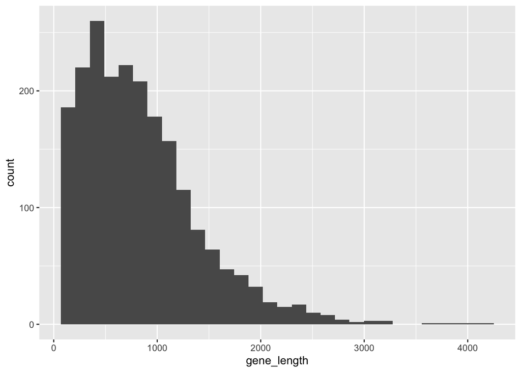

```r
genome_info %>%
dplyr::filter(feature == "gene") %>%
dplyr::mutate(gene_length = end - start) %>%

ggplot() +
    geom_histogram(aes(x = gene_length))
```

## 7.2 Inspect attributes

Let’s see if the GFF file contains protein sequences. The command below chains several operations:

- extracts only the `attributes` column
- on each row of this column, applies an ad-hoc function that splits the attributes into individual character strings (for easier visual inspection)
- randomly samples 4 entries to see what they contain

For **reproducibility**, every time one works with random numbers, the initial value (“seed”) of the random number generator has to be set to a known value. (Computers cannot really generate random numbers, just number sequences that *look* random.)

```r
library(stringr)

set.seed(42)

genome_info %>%
    dplyr::filter(feature == "gene") %>%
    dplyr::select(attributes) %>%
    dplyr::mutate(attributes = lapply(attributes,
                                      function(attr_string) {
                                          stringr::str_split(attr_string, pattern = ";")
                                      })
                  ) %>%
    sample_n(4) %>%
    pull   # extract ("pull") the underlying list from the table so we can print contents
```

```
## [[1]]
## [[1]][[1]]
## [1] "ID=gene1176"            "Name=snp"               "gbkey=Gene"
## [4] "gene=snp"               "locus_tag=VNG_1496G"    "old_locus_tag=VNG1496G"
##
##
## [[2]]
## [[2]][[1]]
## [1] "ID=gene1097"            "Name=htr9"              "gbkey=Gene"
## [4] "gene=htr9"              "locus_tag=VNG_1395G"    "old_locus_tag=VNG1395G"
##
##
## [[3]]
## [[3]][[1]]
## [1] "ID=gene1251"            "Name=gdcH"              "gbkey=Gene"
## [4] "gene=gdcH"              "locus_tag=VNG_1605G"    "old_locus_tag=VNG1605G"
##
##
## [[4]]
## [[4]][[1]]
## [1] "ID=gene633"             "Name=VNG_0804C"         "gbkey=Gene"
## [4] "locus_tag=VNG_0804C"    "old_locus_tag=VNG0804C"
```